# Day 17 - GRU & Seq2Seq - 门控循环单元与编码器-解码器

> 目标: 理解 GRU 如何用两个门简化 LSTM, 以及 Seq2Seq 的编码器-解码器架构

> 核心: GRU = 更新门 + 重置门 (LSTM 的 3 个门 -> 2 个门)

## RNN vs LSTM vs GRU

```
RNN:   h_t = tanh(W * [x_t, h_{t-1}])                       1 组权重
LSTM:  i, f, o, g  四个变换, 细胞状态 C_t                   4 组权重
GRU:   z (更新门) + r (重置门), 没有细胞状态                  3 组权重

精度:   LSTM >= GRU >> RNN   (大数据集 LSTM 略好, 小数据集 GRU 性价比高)
速度:   GRU > LSTM (少一组门, 计算更快)
参数:   GRU 是 LSTM 的 3/4
```

```
========================================
Day 17 - GRU & Seq2Seq
========================================
```

## 1. GRU 的两个门

> GRU (Cho et al., 2014) 把 LSTM 的遗忘门 + 输入门合并成更新门, 去掉输出门, 加入重置门

### 重置门 (Reset Gate) - 决定忘记多少过去

```
r_t = sigmoid(W_r * [h_{t-1}, x_t] + b_r)

作用: 控制前一个隐藏状态 h_{t-1} 有多少被"重置"
  r_t ≈ 0: 忽略过去, 从当前输入重新开始 (短依赖)
  r_t ≈ 1: 保留过去全部信息 (长依赖)
```

### 更新门 (Update Gate) - 决定保留多少旧信息 + 加入多少新信息

```
z_t = sigmoid(W_z * [h_{t-1}, x_t] + b_z)

作用: LSTM 遗忘门 + 输入门的合并
  z_t ≈ 0: 完全用新信息替换旧信息
  z_t ≈ 1: 完全保留旧信息, 忽略当前输入
```

### GRU 完整公式

```
r_t = sigmoid(W_r * [h_{t-1}, x_t])         # 重置门
z_t = sigmoid(W_z * [h_{t-1}, x_t])         # 更新门
n_t = tanh(W_n * [r_t * h_{t-1}, x_t])      # 候选隐藏状态 (使用重置后的过去)
h_t = (1 - z_t) * n_t + z_t * h_{t-1}       # 最终隐藏状态 (更新门平衡新旧)
                                           # ← 跟 LSTM 一样是加法路径!
```

### LSTM vs GRU 对应关系

```
LSTM:   遗忘门 f  + 输入门 i  = GRU 更新门 z
        输出门 o              = GRU 去掉 (h_t 直接等于 C_t 的某种形式)
        重置门                = GRU 新增 (控制过去对候选的贡献)
```

```
输入形状: (5, 4)
隐藏状态形状: (5, 8)
最后时间步 h[:8]: [-0.1866 -0.0563 -0.0282  0.0764  0.1482 -0.024  -0.0024 -0.1103]
```

## 2. PyTorch nn.GRU 使用

> API 跟 nn.RNN/nn.LSTM 完全一致

```
nn.GRU(input_size, hidden_size, num_layers, batch_first, dropout, bidirectional)

输出: (output, hn)
  output: (batch, seq_len, hidden_size * num_directions)
  hn:     (num_layers * num_directions, batch, hidden_size)

GRU 没有细胞状态! 跟 RNN 一样只返回 hn
```

```
参数数量对比:
  RNN:  640  (1 组权重: W_hh)
  GRU:  1,920  (3 组权重: r, z, n)
  LSTM: 2,560 (4 组权重: i, f, o, g)

  GRU / RNN  = 3.0x
  LSTM / GRU = 1.3x
  LSTM / RNN = 4.0x

input:  (4, 7, 10)
output: (4, 7, 20)
hn:     (2, 4, 20)
output[:,-1] == hn[-1]: True
```

## 3. 实战: RNN vs GRU vs LSTM 三兄弟对决

> 相同参数量级下, 三种 RNN 在正弦波预测上的表现

```
训练集: (792, 10, 1)
```

```
RNN: 1,153 params
GRU: 3,393 params
LSTM: 4,513 params
```

```
训练 RNN...
  Epoch 10 | Loss = 0.000005
  Epoch 20 | Loss = 0.000006
  Epoch 30 | Loss = 0.000011
  Epoch 40 | Loss = 0.000001
  Epoch 50 | Loss = 0.000001
RNN 测试 MSE: 0.000001

训练 GRU...
  Epoch 10 | Loss = 0.000008
  Epoch 20 | Loss = 0.000000
  Epoch 30 | Loss = 0.000000
  Epoch 40 | Loss = 0.000000
  Epoch 50 | Loss = 0.000000
GRU 测试 MSE: 0.000000

训练 LSTM...
  Epoch 10 | Loss = 0.000001
  Epoch 20 | Loss = 0.000001
  Epoch 30 | Loss = 0.000001
  Epoch 40 | Loss = 0.000001
  Epoch 50 | Loss = 0.000001
LSTM 测试 MSE: 0.000002
```

[figure not shown]

## 4. Seq2Seq - 编码器-解码器架构

> 前几天的 RNN/LSTM/GRU 都是"一个序列 -> 一个序列" (长度相同)

> Seq2Seq 解决: "一个序列 -> 另一个不同长度的序列"

> 应用: 机器翻译 (英->中), 语音识别, 文本摘要

### 结构

```
编码器 (Encoder)                    解码器 (Decoder)

  x1 -> RNN -> h1                   y0  (起始符)
  x2 -> RNN -> h2                     |
  x3 -> RNN -> h3                     v
  ...               h_enc --------> RNN -> y1 (预测)
  xT -> RNN -> hT   (上下文向量)       |
                                     v
                                   RNN -> y2 (预测)
                                     |
                                    ...
                                  直到输出 <EOS> 为止

关键: 编码器的最后一个隐藏状态 = 整个输入序列的"摘要"
      解码器基于这个摘要, 一步步生成输出
```

### Seq2Seq 的局限

```
1. 信息瓶颈: 整个输入序列压缩成一个向量 h_enc, 长序列信息丢失
2. -> Day 18: Attention 机制让解码器可以"回头看"输入序列的每一步
```

```
Seq2Seq 结构定义完成
  Encoder: input -> embed -> GRU -> context vector
  Decoder: context vector + prev_token -> GRU -> next_token
  Teacher Forcing: 训练时用真实值引导, 加速收敛
```

## 5. Seq2Seq 玩具实战: 字符串反转

> 任务: "hello" -> "olleh" (反转字符串)

> 这个任务很简单, 但完美展示了 Seq2Seq 的工作原理

```
编码器输入: h e l l o
解码器输出: o l l e h

解码器起始符 <SOS>: 告诉模型"开始生成"
解码器终止符 <EOS>: 模型学会"输出结束"
```

```
词表: ['<PAD>', '<SOS>', '<EOS>', 'a', 'b', 'c', 'd', 'e', 'g', 'h', 'l', 'm', 'n', 'o', 'r', 's', 't', 'u', 'w', 'x', 'y', 'z']
词表大小: 22

数据示例:
  <SOS>hello -> <SOS>olleh
  <SOS>world -> <SOS>dlrow
  <SOS>abc<EOS> -> <SOS>cba<EOS>
  <SOS>xyz<EOS> -> <SOS>zyx<EOS>
  <SOS>rnn<EOS> -> <SOS>nnr<EOS>
  <SOS>lstm<EOS> -> <SOS>mtsl<EOS>
  <SOS>gru<EOS> -> <SOS>urg<EOS>
```

```
Seq2Seq 总参数量: 3,222
  Epoch  50/300 | Loss = 0.4962
```

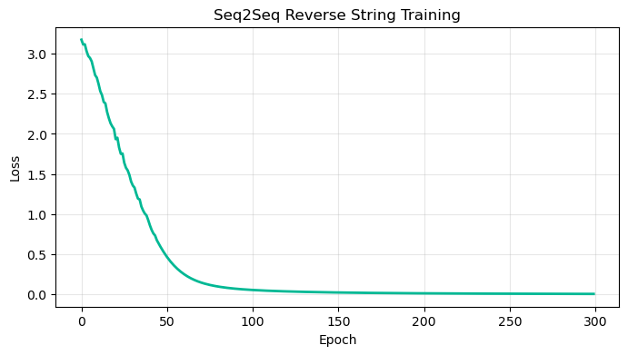

```
测试结果:
输入         期望         预测         正确?
----------------------------------------
hello      olleh      ollehh     ❌
world      dlrow      dlrowh     ❌
abc        cba        cba        ✅
rnn        nnr        nnr        ✅
lstm       mtsl       mtsl       ✅
gru        urg        urg        ✅
```

# Day 17 完成!

## 今天学到了什么

| 概念 | 一句话 |
| --- | --- |
| **GRU** | 更新门 z (合并遗忘+输入) + 重置门 r (控制过去影响) |
| **GRU vs LSTM** | 3 组权重 vs 4 组, 参数更少, 效果接近 |
| **GRU 加法路径** | h_t = (1-z)*n + z*h_{t-1}, 梯度同样不会消失 |
| **Seq2Seq** | 编码器压缩输入 -> 上下文向量 -> 解码器生成输出 |
| **Teacher Forcing** | 训练时用真实值引导, 让解码器学得更快 |
| **信息瓶颈** | 整个序列压缩成一个向量, 长序列会丢失信息 |

## RNN 演化总结

[output not shown]

## 作业 (代码定位)

### [作业 1] 只训练 GRU

**位置:** cell-9, 第 19-27 行: `for name, model in models.items():` 循环

**问题:** 注释掉 RNN 和 LSTM 的训练 (只留 GRU), 训练速度快了多少?

- 提示: 在 `models` 字典里删掉 'RNN' 和 'LSTM' 即可

### [作业 2] 增大 hidden_size

**位置:** cell-8, 第 14-16 行: `RNNPredictor('rnn', 32)` 的 `32`

**问题:** 把 hidden_size 从 32 改成 64, 重新跑 cell-9 和 cell-10, 观察:

- 三种模型的参数量增长了多少?
- 测试 Loss 下降了多少?
- 训练时间增长了多少?

### [作业 3] Teacher Forcing 影响

**位置:** cell-12, 第 42 行: `teacher_forcing_ratio=0.5`

**问题:** 改成 0.0 (完全不用) 和 1.0 (完全用), 训练效果有什么变化?

- teacher_forcing_ratio=0: 自己猜下一个词, 可能学得慢
- teacher_forcing_ratio=1: 全是正确答案, 但测试时可能崩
- 修改后重新跑 cell-15 看 loss 曲线

### [作业 4] 更长的字符串

**位置:** cell-16, 倒数第 6 行: `test_inputs = [...]`

**问题:** 在列表里加一些更长的字符串 (如 'abcdef', 'hello!'), 观察:

- 当字符串长度超过训练集最大长度时, 反转准确率如何?
- 这说明 Seq2Seq 的信息瓶颈问题有多严重?

### [作业 5] 预习

预习 Day 18: Attention (Bahdanau) — 解码器不再只看上下文向量, 可以"回头看"输入序列的每一步